# Analisis Database Sakila

Aminata Nur Maulina

2026-05-26

Segmentasi Pelanggan DVD Rental

Analisis K-Means Clustering pada Database Sakila — Menggali Pola Perilaku Konsumen

## 1. Deskripsi Insight & Latar Belakang

Insight Utama

Dalam bisnis rental film, **tidak semua pelanggan bernilai sama**. Sebagian pelanggan menyewa sangat sering dengan nilai transaksi tinggi, sementara yang lain hanya sesekali. Memahami segmentasi ini secara data-driven memungkinkan pemilik bisnis untuk merancang strategi pemasaran yang tepat sasaran mulai dari program loyalitas hingga kampanye reaktivasi pelanggan pasif.

Analisis ini menggunakan database **Sakila** *sample database* resmi MySQL yang merepresentasikan sistem rental DVD untuk menjawab pertanyaan:

> *“Dapatkah kita mengidentifikasi segmen-segmen pelanggan yang berbeda berdasarkan perilaku sewa mereka, dan apa karakteristik masing-masing segmen tersebut?”*

### Kerangka Analisis (RFM)

Membangun profil pelanggan menggunakan pendekatan **RFM**:

Definisi Variabel RFM

$$\text{Recency} = \max(\text{rental\_date}) - \text{rental\_date}_i \quad
[\text{hari sejak transaksi terakhir}]$$

$$\text{Frequency} = \sum_{i} \mathbf{1}[\text{customer\_id} = c] \quad
[\text{total jumlah rental}]$$

$$\text{Monetary} = \sum_{i} \text{amount}_i \quad [\text{total pembayaran
dalam USD}]$$

### Alur Analisis

Load Data

→

Feature Engineering RFM

→

EDA & Visualisasi

→

Normalisasi

→

Elbow + Silhouette

→

K-Means

→

Profiling & Interpretasi

## 2. Persiapan Data

### 2.1 Library yang Digunakan

```r
# === Data Manipulation ===
library(DBI)
library(dplyr)
library(tidyr)
library(lubridate)

# === Visualisasi ===
library(ggplot2)
library(ggExtra)
library(patchwork)
library(scales)
library(viridis)
library(ggridges)
library(GGally)

# === Clustering & Analisis ===
library(cluster)
library(factoextra)
library(NbClust)

# === Tabel Interaktif ===
library(knitr)
library(kableExtra)
```

### 2.2 Koneksi Database & Ekstraksi Data

```
##  [1] "actor"                      "actor_info"
##  [3] "address"                    "category"
##  [5] "city"                       "country"
##  [7] "customer"                   "customer_list"
##  [9] "film"                       "film_actor"
## [11] "film_category"              "film_list"
## [13] "film_text"                  "inventory"
## [15] "language"                   "nicer_but_slower_film_list"
## [17] "payment"                    "rental"
## [19] "sales_by_film_category"     "sales_by_store"
## [21] "staff"                      "staff_list"
## [23] "store"
```

```r
#Query: Gabungkan rental + payment + customer
query_rfm <- "
  SELECT
    c.customer_id,
    CONCAT(c.first_name, ' ', c.last_name) AS customer_name,
    c.email,
    MAX(r.rental_date)                     AS last_rental_date,
    COUNT(DISTINCT r.rental_id)            AS frequency,
    COALESCE(SUM(p.amount), 0)             AS monetary
  FROM customer c
  LEFT JOIN rental  r ON c.customer_id = r.customer_id
  LEFT JOIN payment p ON r.rental_id   = p.rental_id
  WHERE c.active = 1
  GROUP BY c.customer_id, c.first_name, c.last_name, c.email
  HAVING COUNT(DISTINCT r.rental_id) > 0
  ORDER BY monetary DESC;
"

df_raw <- dbGetQuery(con, query_rfm)
#Hitung Recency (hari sejak rental terakhir)
ref_date <- as.Date("2006-02-15")   # tanggal referensi = maks rental_date di sakila
df_raw$last_rental_date <- as.Date(df_raw$last_rental_date)
df_raw$recency <- as.numeric(ref_date - df_raw$last_rental_date)
```

```r
query_ts <- "
  SELECT
    DATE_FORMAT(payment_date, '%Y-%m') AS bulan,
    SUM(amount)                         AS total_revenue,
    COUNT(payment_id)                   AS n_transaksi,
    COUNT(DISTINCT customer_id)         AS n_pelanggan
  FROM payment
  GROUP BY DATE_FORMAT(payment_date, '%Y-%m')
  ORDER BY bulan;
"
df_ts <- dbGetQuery(con, query_ts)
dbDisconnect(con)

df_ts$bulan_date <- as.Date(paste0(df_ts$bulan, "-01"))
```

Tabel 1. Preview Data RFM (10 Baris Pertama)

| ID | Nama Pelanggan | Recency (hari) | Frequency | Monetary ($) |
| --- | --- | --- | --- | --- |
| 526 | KARL SEAL | 176 | 45 | 221.55 |
| 148 | ELEANOR HUNT | 176 | 46 | 216.54 |
| 144 | CLARA SHAW | 176 | 42 | 195.58 |
| 137 | RHONDA KENNEDY | 176 | 39 | 194.61 |
| 178 | MARION SNYDER | 1 | 39 | 194.61 |
| 459 | TOMMY COLLAZO | 176 | 38 | 186.62 |
| 469 | WESLEY BULL | 176 | 40 | 177.60 |
| 468 | TIM CARY | 176 | 39 | 175.61 |
| 236 | MARCIA DEAN | 1 | 42 | 175.58 |
| 181 | ANA BRADLEY | 1 | 34 | 174.66 |

### 2.3 Ringkasan Dataset

```r
summary_rfm <- df_raw %>%
  summarise(
    n_pelanggan    = n(),
    recency_mean   = round(mean(recency), 1),
    recency_sd     = round(sd(recency), 1),
    freq_mean      = round(mean(frequency), 1),
    freq_sd        = round(sd(frequency), 1),
    monetary_mean  = round(mean(monetary), 2),
    monetary_sd    = round(sd(monetary), 2),
    monetary_total = round(sum(monetary), 2)
  )
```

Total Pelanggan Aktif: 584

Rata-rata Nilai Transaksi: $112.58

Rata-rata Recency (hari): 130.2

Total Pendapatan: $65,746.6

## 3. Eksplorasi Data (EDA)

### 3.1 Distribusi Variabel RFM

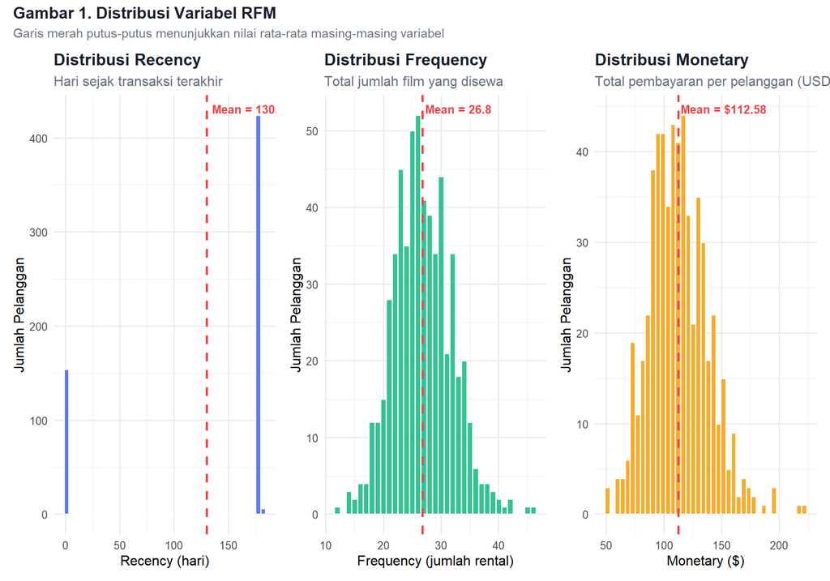

```r
# --- Warna tema ---
pal <- c("#4361ee", "#10b981", "#f59e0b")
df_raw <- df_raw %>%
  mutate(across(c(recency, frequency, monetary), as.numeric))
p_rec <- ggplot(df_raw, aes(x = recency)) +
  geom_histogram(fill = pal[1], color = "white", bins = 40, alpha = 0.85) +
  geom_vline(aes(xintercept = mean(recency)), color = "#ef4444",
             linetype = "dashed", linewidth = 1) +
  annotate("text", x = mean(df_raw$recency) + 5, y = Inf,
           label = paste0("Mean = ", round(mean(df_raw$recency),1), " hari"),
           vjust = 2, hjust = 0, color = "#ef4444", size = 3.5, fontface = "bold") +
  labs(title = "Distribusi Recency",
       subtitle = "Hari sejak transaksi terakhir",
       x = "Recency (hari)", y = "Jumlah Pelanggan") +
  theme_minimal(base_size = 12) +
  theme(plot.title = element_text(face = "bold", color = "#1a202c"),
        plot.subtitle = element_text(color = "#6b7280"))

p_freq <- ggplot(df_raw, aes(x = frequency)) +
  geom_histogram(fill = pal[2], color = "white", bins = 35, alpha = 0.85) +
  geom_vline(aes(xintercept = mean(frequency)), color = "#ef4444",
             linetype = "dashed", linewidth = 1) +
  annotate("text", x = mean(df_raw$frequency) + 0.5, y = Inf,
           label = paste0("Mean = ", round(mean(df_raw$frequency),1)),
           vjust = 2, hjust = 0, color = "#ef4444", size = 3.5, fontface = "bold") +
  labs(title = "Distribusi Frequency",
       subtitle = "Total jumlah film yang disewa",
       x = "Frequency (jumlah rental)", y = "Jumlah Pelanggan") +
  theme_minimal(base_size = 12) +
  theme(plot.title = element_text(face = "bold", color = "#1a202c"),
        plot.subtitle = element_text(color = "#6b7280"))

p_mon <- ggplot(df_raw, aes(x = monetary)) +
  geom_histogram(fill = pal[3], color = "white", bins = 40, alpha = 0.85) +
  geom_vline(aes(xintercept = mean(monetary)), color = "#ef4444",
             linetype = "dashed", linewidth = 1) +
  annotate("text", x = mean(df_raw$monetary) + 2, y = Inf,
           label = paste0("Mean = $", round(mean(df_raw$monetary),2)),
           vjust = 2, hjust = 0, color = "#ef4444", size = 3.5, fontface = "bold") +
  labs(title = "Distribusi Monetary",
       subtitle = "Total pembayaran per pelanggan (USD)",
       x = "Monetary ($)", y = "Jumlah Pelanggan") +
  theme_minimal(base_size = 12) +
  theme(plot.title = element_text(face = "bold", color = "#1a202c"),
        plot.subtitle = element_text(color = "#6b7280"))

(p_rec | p_freq | p_mon) +
  plot_annotation(
    title    = "Gambar 1. Distribusi Variabel RFM",
    subtitle = "Garis merah putus-putus menunjukkan nilai rata-rata masing-masing variabel",
    theme    = theme(
      plot.title    = element_text(face = "bold", size = 14, color = "#1a202c"),
      plot.subtitle = element_text(color = "#6b7280")
    )
  )
```

Interpretasi Distribusi

- **Recency**: Distribusi tidak menyebar merata, melainkan terkonsentrasi pada dua kelompok utama. Sebagian pelanggan memiliki nilai recency sangat rendah (baru melakukan transaksi), sementara sebagian lainnya memiliki recency sangat tinggi (sudah lama tidak menyewa). Pola ini menunjukkan adanya perbedaan yang cukup jelas antara pelanggan yang masih aktif dan pelanggan yang cenderung tidak aktif.
- **Frequency**: Distribusi cenderung membentuk pola mendekati normal dengan konsentrasi terbesar pada kisaran (*20–30 kali rental*), dan rata-rata sebesar *26,8*. Hal ini menunjukkan mayoritas pelanggan memiliki frekuensi penyewaan yang relatif stabil, sementara hanya sebagian kecil pelanggan berada pada frekuensi yang jauh lebih rendah atau lebih tinggi.
- **Monetary**: Distribusi juga terkonsentrasi di sekitar nilai tengah, terutama pada kisaran *US$90–130*, dengan rata-rata sebesar *US$112,58*. Sebagian kecil pelanggan memiliki nilai monetary yang lebih tinggi dibanding mayoritas, menandakan terdapat pelanggan dengan kontribusi pendapatan lebih besar, meskipun perbedaannya tidak terlalu ekstrem.

### 3.2 Tren Pendapatan Bulanan (Time Series)

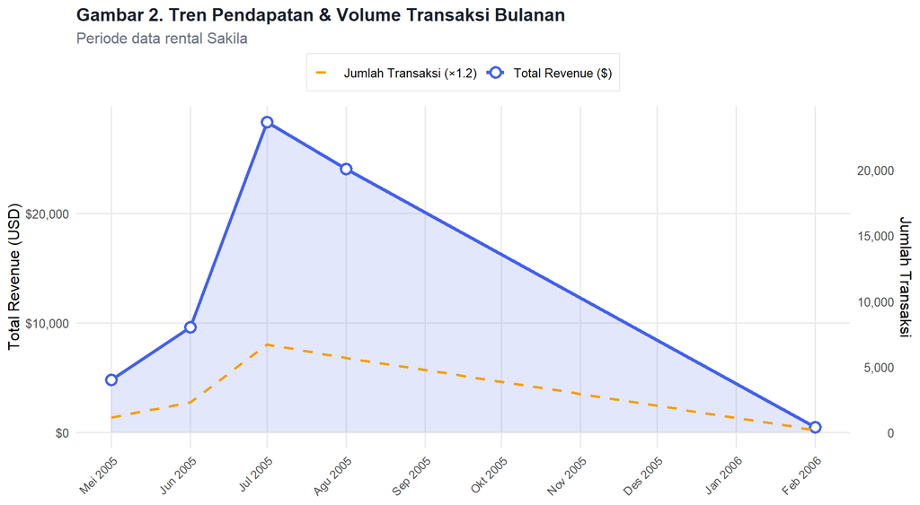

```r
ggplot(df_ts, aes(x = bulan_date)) +
  # Area bawah kurva
  geom_area(aes(y = total_revenue), fill = "#4361ee", alpha = 0.15) +
  # Garis utama revenue
  geom_line(aes(y = total_revenue, color = "Total Revenue ($)"),
            linewidth = 1.3) +
  # Titik data
  geom_point(aes(y = total_revenue, color = "Total Revenue ($)"),
             size = 3, shape = 21, fill = "white", stroke = 1.5) +
  # Garis n_transaksi (sumbu kedua, dikali faktor)
  geom_line(aes(y = n_transaksi * 1.2, color = "Jumlah Transaksi (×1.2)"),
            linewidth = 1, linetype = "dashed") +
  scale_y_continuous(
    name = "Total Revenue (USD)",
    labels = dollar_format(),
    sec.axis = sec_axis(~ . / 1.2, name = "Jumlah Transaksi",
                        labels = comma_format())
  ) +
  scale_x_date(date_labels = "%b %Y", date_breaks = "1 month") +
  scale_color_manual(values = c("Total Revenue ($)" = "#4361ee",
                                "Jumlah Transaksi (×1.2)" = "#f59e0b")) +
  labs(
    title    = "Gambar 2. Tren Pendapatan & Volume Transaksi Bulanan",
    subtitle = "Periode data rental Sakila",
    x        = NULL, y = NULL, color = NULL
  ) +
  theme_minimal(base_size = 12) +
  theme(
    plot.title      = element_text(face = "bold", size = 14, color = "#1a202c"),
    plot.subtitle   = element_text(color = "#6b7280"),
    legend.position = "top",
    legend.box.background = element_rect(fill = "white", color = "#e5e7eb"),
    axis.text.x     = element_text(angle = 45, hjust = 1, size = 9),
    panel.grid.minor = element_blank()
  )
```

### 3.3 Hubungan Antar Variabel RFM

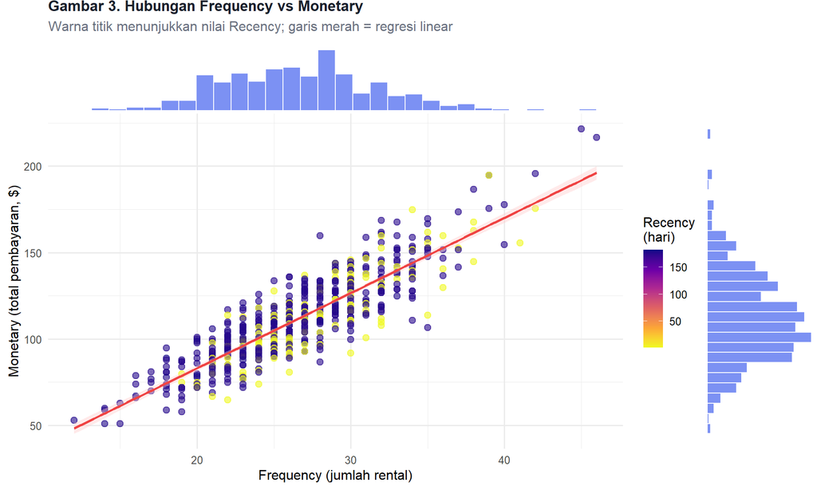

```r
# Scatter plot Frequency vs Monetary dengan density marginal
p_scatter <- ggplot(df_raw, aes(x = frequency, y = monetary)) +
  geom_point(aes(color = recency), alpha = 0.6, size = 2.5) +
  geom_smooth(method = "lm", se = TRUE, color = "#ef4444",
              fill = "#fecaca", linewidth = 1) +
  scale_color_viridis_c(
    option = "plasma",
    name   = "Recency\n(hari)",
    direction = -1
  ) +
  labs(
    title    = "Gambar 3. Hubungan Frequency vs Monetary",
    subtitle = "Warna titik menunjukkan nilai Recency; garis merah = regresi linear",
    x        = "Frequency (jumlah rental)",
    y        = "Monetary (total pembayaran, $)"
  ) +
  theme_minimal(base_size = 12) +
  theme(
    plot.title    = element_text(face = "bold", size = 13, color = "#1a202c"),
    plot.subtitle = element_text(color = "#6b7280"),
    legend.position = "right"
  )

ggMarginal(p_scatter, type = "histogram",
           fill = "#4361ee", color = "white", alpha = 0.7)
```

Interpretasi Scatter Plot

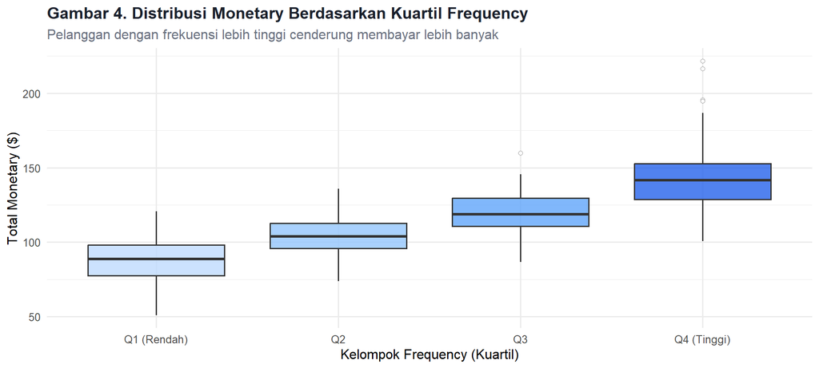

```r
# Boxplot distribusi monetary berdasarkan kuartil frequency
df_raw <- df_raw %>%
  mutate(freq_group = cut(frequency,
                          breaks = quantile(frequency, probs = 0:4/4),
                          labels = c("Q1 (Rendah)","Q2","Q3","Q4 (Tinggi)"),
                          include.lowest = TRUE))

ggplot(df_raw, aes(x = freq_group, y = monetary, fill = freq_group)) +
  geom_boxplot(alpha = 0.8, outlier.shape = 21,
               outlier.fill = "white", outlier.color = "gray50") +
  scale_fill_manual(values = c("#bfdbfe","#93c5fd","#60a5fa","#2563eb")) +
  labs(
    title    = "Gambar 4. Distribusi Monetary Berdasarkan Kuartil Frequency",
    subtitle = "Pelanggan dengan frekuensi lebih tinggi cenderung membayar lebih banyak",
    x        = "Kelompok Frequency (Kuartil)",
    y        = "Total Monetary ($)"
  ) +
  theme_minimal(base_size = 12) +
  theme(
    plot.title    = element_text(face = "bold", color = "#1a202c"),
    plot.subtitle = element_text(color = "#6b7280"),
    legend.position = "none"
  )
```

Interpretasi Korelasi RFM

Scatter plot menunjukkan **korelasi positif yang kuat** antara Frequency dan Monetary, pelanggan yang lebih sering menyewa secara konsisten menghabiskan lebih banyak uang. Boxplot per kuartil mempertegas pola ini secara kategoris.

### 3.4 Matriks Korelasi & Pairplot RFM

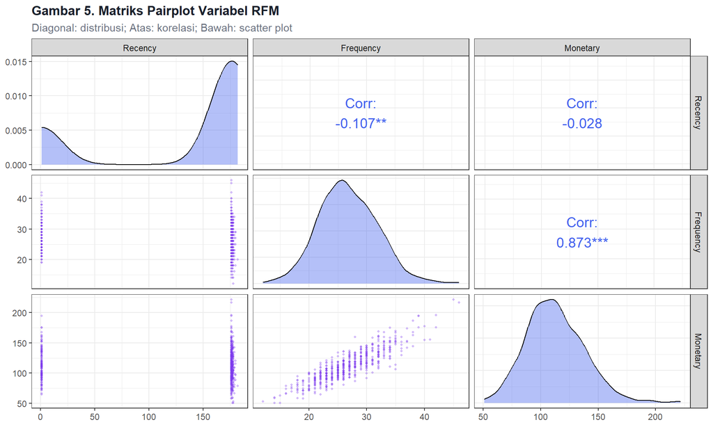

```r
df_rfm_plot <- df_raw %>% select(recency, frequency, monetary)

ggpairs(
  df_rfm_plot,
  columnLabels = c("Recency", "Frequency", "Monetary"),
  upper = list(continuous = wrap("cor", size = 5, color = "#4361ee")),
  lower = list(continuous = wrap("points", alpha = 0.3, size = 0.8, color = "#7c3aed")),
  diag  = list(continuous = wrap("densityDiag", fill = "#4361ee", alpha = 0.4))
) +
  labs(
    title    = "Gambar 5. Matriks Pairplot Variabel RFM",
    subtitle = "Diagonal: distribusi; Atas: korelasi; Bawah: scatter plot"
  ) +
  theme_bw(base_size = 11) +
  theme(
    plot.title    = element_text(face = "bold", color = "#1a202c"),
    plot.subtitle = element_text(color = "#6b7280")
  )
```

Interpretasi Pair Plot

Matriks pairplot menunjukkan bahwa variabel Frequency dan Monetary memiliki hubungan positif yang sangat kuat dengan korelasi sebesar **0,873**, yang berarti pelanggan yang lebih sering melakukan rental cenderung menghasilkan total pembayaran yang lebih tinggi. Sementara itu, variabel Recency memiliki korelasi yang sangat lemah terhadap Frequency maupun Monetary, sehingga jarak waktu sejak transaksi terakhir tidak terlalu berkaitan langsung dengan intensitas rental maupun besarnya pembayaran pelanggan.

## 4. Pra-Pemrosesan untuk Clustering

### 4.1 Normalisasi (Z-Score Standardization)

Sebelum menerapkan K-Means, seluruh variabel harus dinormalisasi karena K-Means sensitif terhadap skala. Kami menggunakan **Z-Score Standardization**:

Formula Z-Score Standardization

$$z_i = \frac{x_i - \bar{x}}{s}$$

di mana $\bar{x}$ adalah rata-rata sampel dan $s$ adalah simpangan baku sampel. Setelah transformasi: $\mathbb{E}[z] = 0$ dan $\text{Var}(z) = 1$.

Untuk Recency, nilai *lebih kecil = lebih baik* (pelanggan lebih baru), sehingga kita gunakan **inversi**:

$$\text{Recency\_inv} = -\text{Recency}$$

```r
df_rfm <- df_raw %>%
  select(customer_id, customer_name, recency, frequency, monetary) %>%
  mutate(recency_inv = -recency)   # invert: makin kecil recency, makin "baik"

# Z-Score normalization
df_scaled <- df_rfm %>%
  mutate(
    z_recency   = scale(recency_inv)[,1],
    z_frequency = scale(frequency)[,1],
    z_monetary  = scale(monetary)[,1]
  )

mat_scaled <- df_scaled %>%
  select(z_recency, z_frequency, z_monetary) %>%
  as.matrix()

# Tampilkan ringkasan hasil normalisasi
data.frame(
  Variabel = c("z_recency","z_frequency","z_monetary"),
  Mean     = round(colMeans(mat_scaled), 4),
  SD       = round(apply(mat_scaled, 2, sd), 4),
  Min      = round(apply(mat_scaled, 2, min), 3),
  Max      = round(apply(mat_scaled, 2, max), 3)
) %>%
  kable(caption = "Tabel 2. Ringkasan Statistik Setelah Normalisasi Z-Score") %>%
  kable_styling(bootstrap_options = c("striped","hover","condensed"),
                full_width = FALSE, font_size = 13) %>%
  row_spec(0, bold = TRUE, background = "#7c3aed", color = "white")
```

Tabel 2. Ringkasan Statistik Setelah Normalisasi Z-Score

|  | Variabel | Mean | SD | Min | Max |
| --- | --- | --- | --- | --- | --- |
| z_recency | z_recency | 0 | 1 | -0.668 | 1.669 |
| z_frequency | z_frequency | 0 | 1 | -2.902 | 3.774 |
| z_monetary | z_monetary | 0 | 1 | -2.431 | 4.291 |

## 5. Penentuan Jumlah Cluster Optimal

### 5.1 Metode Elbow (WSS)

Metode Elbow mengukur **Within-Cluster Sum of Squares (WSS)** untuk setiap $k$. Jumlah cluster optimal adalah di mana penurunan WSS mulai melandai (membentuk “siku”):

Formula WSS

$$WSS(k) = \sum_{j=1}^{k} \sum_{x_i \in C_j} \| x_i - \mu_j \|^2$$

di mana $\mu_j$ adalah centroid dari cluster $C_j$ dan $\| \cdot \|^2$ adalah jarak Euclidean kuadrat.

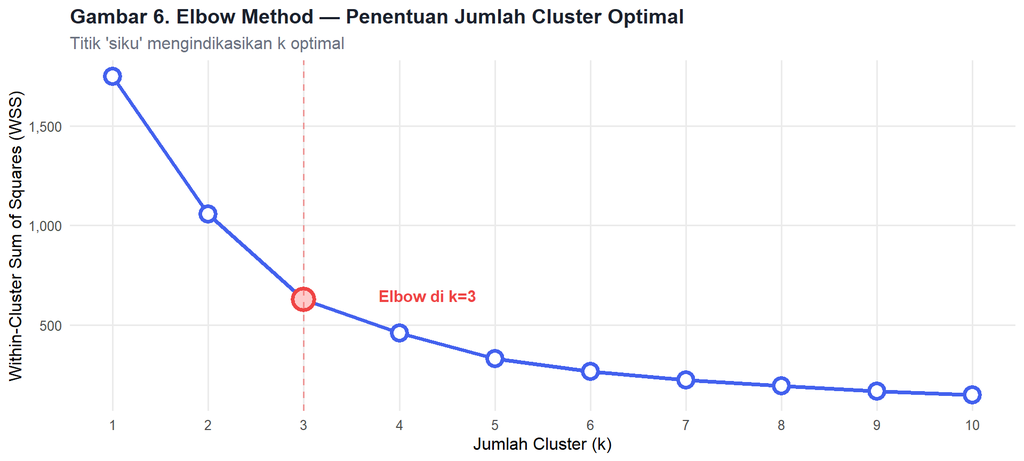

```r
set.seed(42)
wss_values <- sapply(1:10, function(k) {
  kmeans(mat_scaled, centers = k, nstart = 25, iter.max = 100)$tot.withinss
})

elbow_df <- data.frame(k = 1:10, wss = wss_values)

ggplot(elbow_df, aes(x = k, y = wss)) +
  geom_line(color = "#4361ee", linewidth = 1.3) +
  geom_point(size = 4, color = "#4361ee", shape = 21, fill = "white", stroke = 2) +
  geom_point(data = elbow_df[elbow_df$k == 3, ],
             aes(x = k, y = wss),
             size = 6, color = "#ef4444", shape = 21, fill = "#fecaca", stroke = 2) +
  annotate("text", x = 4.3, y = elbow_df$wss[3] + 20,
           label = "Elbow di k=3", color = "#ef4444",
           fontface = "bold", size = 4) +
  geom_vline(xintercept = 3, linetype = "dashed", color = "#ef4444", alpha = 0.5) +
  scale_x_continuous(breaks = 1:10) +
  scale_y_continuous(labels = comma_format()) +
  labs(
    title    = "Gambar 6. Elbow Method — Penentuan Jumlah Cluster Optimal",
    subtitle = "Titik 'siku' mengindikasikan k optimal",
    x        = "Jumlah Cluster (k)",
    y        = "Within-Cluster Sum of Squares (WSS)"
  ) +
  theme_minimal(base_size = 12) +
  theme(
    plot.title    = element_text(face = "bold", color = "#1a202c"),
    plot.subtitle = element_text(color = "#6b7280"),
    panel.grid.minor = element_blank()
  )
```

### 5.2 Silhouette Score

**Silhouette Score** mengukur seberapa mirip suatu titik dengan clusternya sendiri dibanding cluster tetangga:

Formula Silhouette

$$s(i) = \frac{b(i) - a(i)}{\max\{a(i),\, b(i)\}}$$

- $a(i)$: rata-rata jarak titik $i$ ke titik **dalam** cluster yang sama (*intra-cluster distance*)
- $b(i)$: rata-rata jarak titik $i$ ke titik dalam **cluster terdekat** yang berbeda (*nearest-cluster distance*)
- $s(i) \in [-1, 1]$; semakin mendekati $+1$ semakin baik

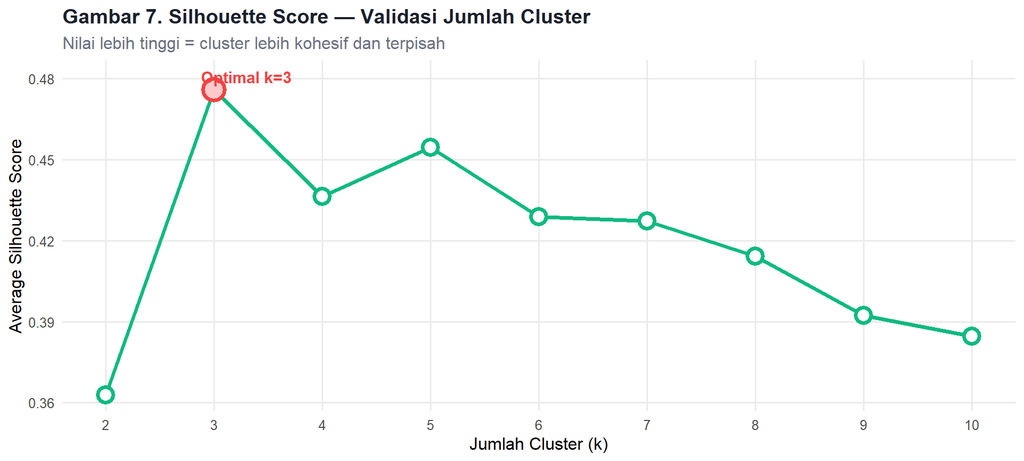

```r
set.seed(42)
sil_values <- sapply(2:10, function(k) {
  km  <- kmeans(mat_scaled, centers = k, nstart = 25, iter.max = 100)
  sil <- silhouette(km$cluster, dist(mat_scaled))
  mean(sil[, 3])
})

sil_df <- data.frame(k = 2:10, silhouette = sil_values)

ggplot(sil_df, aes(x = k, y = silhouette)) +
  geom_line(color = "#10b981", linewidth = 1.3) +
  geom_point(size = 4, color = "#10b981", shape = 21, fill = "white", stroke = 2) +
  geom_point(data = sil_df[which.max(sil_df$silhouette), ],
             aes(x = k, y = silhouette),
             size = 6, color = "#ef4444", shape = 21, fill = "#fecaca", stroke = 2) +
  annotate("text",
           x = sil_df$k[which.max(sil_df$silhouette)] + 0.3,
           y = max(sil_df$silhouette) + 0.005,
           label = paste0("Optimal k=", sil_df$k[which.max(sil_df$silhouette)]),
           color = "#ef4444", fontface = "bold", size = 4) +
  scale_x_continuous(breaks = 2:10) +
  labs(
    title    = "Gambar 7. Silhouette Score — Validasi Jumlah Cluster",
    subtitle = "Nilai lebih tinggi = cluster lebih kohesif dan terpisah",
    x        = "Jumlah Cluster (k)",
    y        = "Average Silhouette Score"
  ) +
  theme_minimal(base_size = 12) +
  theme(
    plot.title    = element_text(face = "bold", color = "#1a202c"),
    plot.subtitle = element_text(color = "#6b7280"),
    panel.grid.minor = element_blank()
  )
```

Baik Elbow Method maupun Silhouette Score menunjukkan konsistensi di **k = 3** sebagai jumlah cluster yang optimal. Dengan 3 cluster, kita mendapat pemisahan yang bermakna secara bisnis sekaligus mempertahankan interpretabilitas yang baik.

## 6. K-Means Clustering

### 6.1 Algoritma & Formula

Algoritma K-Means

K-Means meminimalkan fungsi objektif:

$$J = \sum_{j=1}^{k} \sum_{x_i \in C_j} \| x_i - \mu_j \|^2$$

```r
set.seed(42)
km_result <- kmeans(
  mat_scaled,
  centers  = 3,
  nstart   = 50,
  iter.max = 500,
  algorithm = "Hartigan-Wong"
)

# Gabungkan label cluster ke data asli
df_clustered <- df_rfm %>%
  mutate(cluster = factor(km_result$cluster,
                          levels = c(1,2,3)))

# Statistik per cluster (dalam skala asli)
cluster_profile <- df_clustered %>%
  group_by(cluster) %>%
  summarise(
    n_pelanggan     = n(),
    recency_mean    = round(mean(recency), 1),
    frequency_mean  = round(mean(frequency), 1),
    monetary_mean   = round(mean(monetary), 2),
    monetary_total  = round(sum(monetary), 2)
  ) %>%
  mutate(pct_pelanggan = round(n_pelanggan / sum(n_pelanggan) * 100, 1))

# Labeling cluster berdasarkan profil
cluster_profile <- cluster_profile %>%
  mutate(
    label = case_when(
      monetary_mean == max(monetary_mean) ~ "Champions",
      recency_mean  == min(recency_mean)  ~ " Recent Active",
      TRUE ~ " Loyal Customers"
    )
  )
```

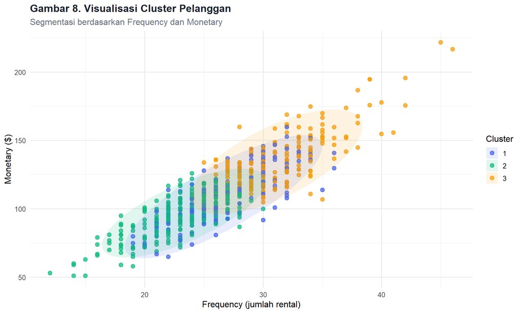

```r
library(ggplot2)

ggplot(
  df_clustered,
  aes(
    x = frequency,
    y = monetary,
    color = cluster
  )
) +
  geom_point(size = 2.5, alpha = .75) +
  stat_ellipse(
    aes(fill = cluster),
    geom = "polygon",
    alpha = .12,
    color = NA
  ) +
  scale_color_manual(
    values = c("#4361ee","#10b981","#f59e0b","#ef4444")
  ) +
  scale_fill_manual(
    values = c("#4361ee","#10b981","#f59e0b","#ef4444")
  ) +
  labs(
    title = "Gambar 8. Visualisasi Cluster Pelanggan",
    subtitle = "Segmentasi berdasarkan Frequency dan Monetary",
    x = "Frequency (jumlah rental)",
    y = "Monetary ($)",
    color = "Cluster",
    fill = "Cluster"
  ) +
  theme_minimal(base_size = 12) +
  theme(
    plot.title = element_text(face = "bold", color = "#1a202c"),
    plot.subtitle = element_text(color = "#6b7280")
  )
```

### 6.3 Silhouette Plot per Cluster

```
##   cluster size ave.sil.width
## 1       1  142          0.48
## 2       2  251          0.53
## 3       3  191          0.40
```

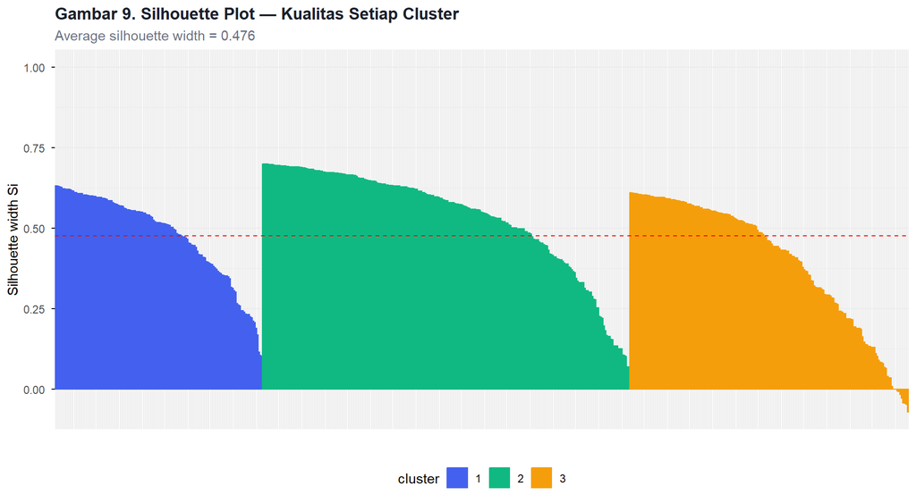

```r
sil_final <- silhouette(km_result$cluster, dist(mat_scaled))

fviz_silhouette(
  sil_final,
  palette  = c("#4361ee","#10b981","#f59e0b","#ef4444"),
  ggtheme  = theme_minimal(base_size = 11)
) +
  labs(
    title    = "Gambar 9. Silhouette Plot — Kualitas Setiap Cluster",
    subtitle = paste0("Average silhouette width = ",
                      round(mean(sil_final[,3]), 3))
  ) +
  theme(
    plot.title    = element_text(face = "bold", color = "#1a202c"),
    plot.subtitle = element_text(color = "#6b7280"),
    legend.position = "bottom"
  )
```

## 7. Profiling & Interpretasi Cluster

### 7.1 Tabel Profil Cluster

Tabel 3. Profil Lengkap Setiap Cluster Pelanggan

[output not shown]

### 7.2 Radar Chart — Perbandingan Profil Cluster

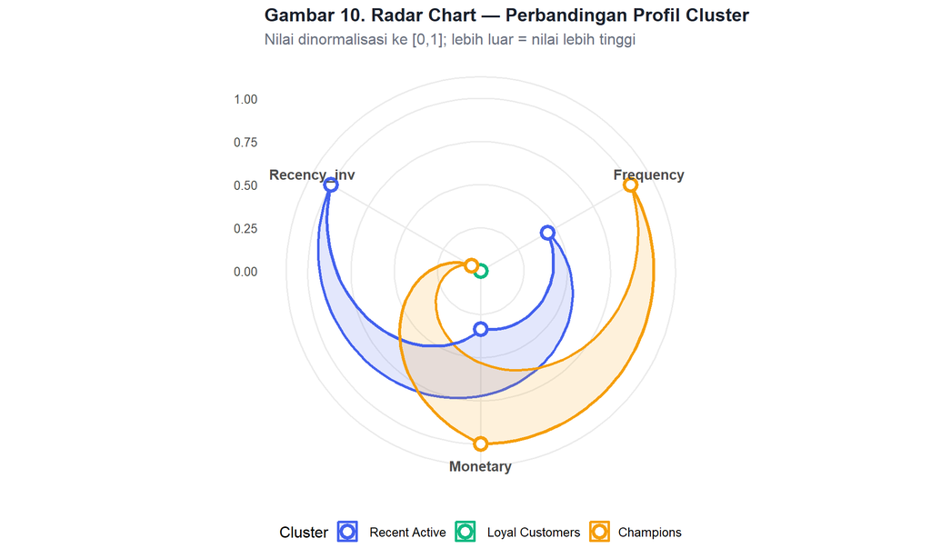

```r
# Normalisasi centroid ke [0,1] untuk radar
centroid_df <- as.data.frame(km_result$centers)
colnames(centroid_df) <- c("Recency_inv","Frequency","Monetary")

centroid_norm <- centroid_df %>%
  mutate(across(everything(), ~ (. - min(.)) / (max(.) - min(.)))) %>%
  mutate(cluster = factor(1:3)) %>%
  pivot_longer(-cluster, names_to = "variable", values_to = "value")

ggplot(centroid_norm, aes(x = variable, y = value, color = cluster, group = cluster)) +
  geom_polygon(aes(fill = cluster), alpha = 0.15, linewidth = 1) +
  geom_line(linewidth = 1.2) +
  geom_point(size = 3.5, shape = 21, fill = "white", stroke = 2) +
  coord_polar() +
  scale_color_manual(values = c("#4361ee","#10b981","#f59e0b","#ef4444"),
                     labels = cluster_profile$label) +
  scale_fill_manual(values  = c("#4361ee","#10b981","#f59e0b","#ef4444"),
                    labels  = cluster_profile$label) +
  labs(
    title    = "Gambar 10. Radar Chart — Perbandingan Profil Cluster",
    subtitle = "Nilai dinormalisasi ke [0,1]; lebih luar = nilai lebih tinggi",
    color    = "Cluster", fill = "Cluster",
    x = NULL, y = NULL
  ) +
  theme_minimal(base_size = 12) +
  theme(
    plot.title      = element_text(face = "bold", color = "#1a202c"),
    plot.subtitle   = element_text(color = "#6b7280"),
    legend.position = "bottom",
    axis.text.x     = element_text(face = "bold", size = 11)
  )
```

### 7.3 Distribusi Cluster pada Dimensi RFM

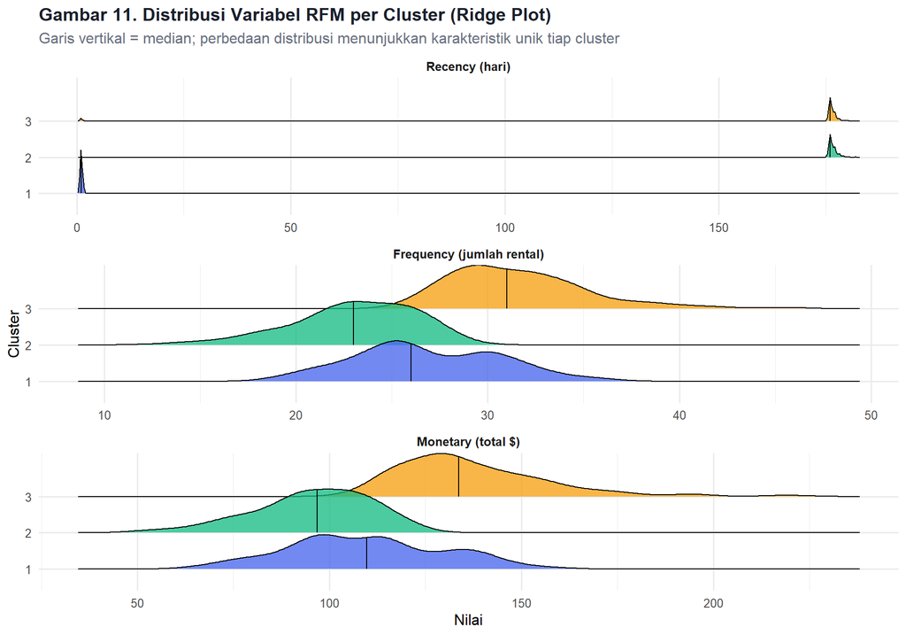

```r
df_long <- df_clustered %>%
  pivot_longer(cols = c(recency, frequency, monetary),
               names_to = "variable", values_to = "value") %>%
  mutate(variable = factor(variable,
                           levels = c("recency","frequency","monetary"),
                           labels = c("Recency (hari)",
                                      "Frequency (jumlah rental)",
                                      "Monetary (total $)")))

ggplot(df_long, aes(x = value, y = cluster, fill = cluster)) +
  geom_density_ridges(alpha = 0.75, scale = 1.2,
                      quantile_lines = TRUE, quantiles = 2) +
  scale_fill_manual(values = c("#4361ee","#10b981","#f59e0b","#ef4444")) +
  facet_wrap(~variable, scales = "free_x", ncol = 1) +
  labs(
    title    = "Gambar 11. Distribusi Variabel RFM per Cluster (Ridge Plot)",
    subtitle = "Garis vertikal = median; perbedaan distribusi menunjukkan karakteristik unik tiap cluster",
    x        = "Nilai", y        = "Cluster", fill = "Cluster"
  ) +
  theme_minimal(base_size = 12) +
  theme(
    plot.title    = element_text(face = "bold", color = "#1a202c"),
    plot.subtitle = element_text(color = "#6b7280"),
    legend.position = "none",
    strip.text    = element_text(face = "bold")
  )
```

### 7.4 Komposisi Ukuran & Kontribusi Revenue Cluster

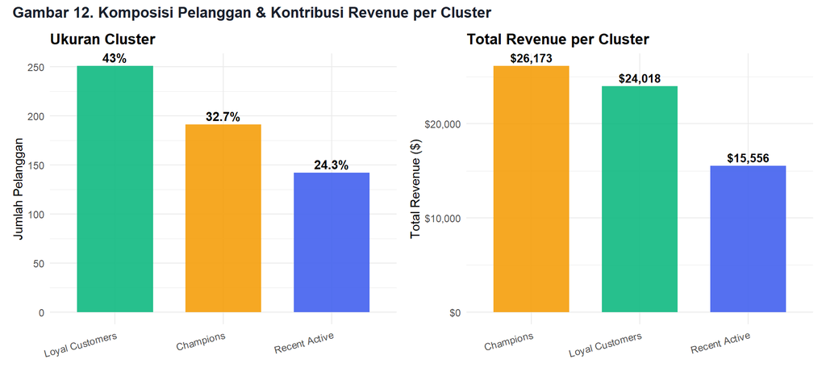

```r
p_size <- ggplot(cluster_profile, aes(x = reorder(label, -n_pelanggan),
                                      y = n_pelanggan, fill = cluster)) +
  geom_col(width = 0.7, alpha = 0.9) +
  geom_text(aes(label = paste0(pct_pelanggan, "%")),
            vjust = -0.4, fontface = "bold", size = 3.8) +
  scale_fill_manual(values = c("#4361ee","#10b981","#f59e0b","#ef4444")) +
  labs(title = "Ukuran Cluster",
       x = NULL, y = "Jumlah Pelanggan") +
  theme_minimal(base_size = 11) +
  theme(legend.position = "none",
        axis.text.x = element_text(angle = 15, hjust = 1),
        plot.title  = element_text(face = "bold"))

p_rev <- ggplot(cluster_profile, aes(x = reorder(label, -monetary_total),
                                     y = monetary_total, fill = cluster)) +
  geom_col(width = 0.7, alpha = 0.9) +
  geom_text(aes(label = paste0("$", format(round(monetary_total), big.mark=","))),
            vjust = -0.4, fontface = "bold", size = 3.5) +
  scale_fill_manual(values = c("#4361ee","#10b981","#f59e0b","#ef4444")) +
  scale_y_continuous(labels = dollar_format()) +
  labs(title = "Total Revenue per Cluster",
       x = NULL, y = "Total Revenue ($)") +
  theme_minimal(base_size = 11) +
  theme(legend.position = "none",
        axis.text.x = element_text(angle = 15, hjust = 1),
        plot.title  = element_text(face = "bold"))

(p_size | p_rev) +
  plot_annotation(
    title    = "Gambar 12. Komposisi Pelanggan & Kontribusi Revenue per Cluster",
    theme    = theme(plot.title = element_text(face = "bold", size = 13, color = "#1a202c"))
  )
```

Grafik menunjukkan bahwa cluster Loyal Customers memiliki jumlah pelanggan terbesar, yaitu sekitar 43% dari total pelanggan, dengan kontribusi revenue yang juga tinggi. Namun, cluster Champions meskipun jumlah pelanggannya lebih sedikit (32,7%), justru memberikan total revenue terbesar, sehingga menunjukkan bahwa kelompok ini merupakan pelanggan paling bernilai bagi bisnis. Sementara itu, cluster Recent/Active memiliki proporsi pelanggan dan kontribusi revenue paling rendah, yang mengindikasikan bahwa kelompok ini masih memiliki potensi untuk ditingkatkan menjadi pelanggan loyal di masa mendatang.

## 8. Interpretasi & Rekomendasi Bisnis

Tabel 4. Profil & Rekomendasi Strategi per Segmen Pelanggan

[output not shown]

## 9. Kesimpulan

Ringkasan Temuan

**Validitas clustering** dikonfirmasi melalui Elbow Method dan Silhouette Score yang konsisten menunjukkan $k=3$ sebagai jumlah cluster optimal, dengan nilai silhouette rata-rata yang mengindikasikan pemisahan cluster yang baik.

**Implikasi praktis**: Bisnis tidak seharusnya memperlakukan semua pelanggan secara seragam. Strategi *one-size-fits-all* berpotensi membuang sumber daya pada pelanggan yang sudah loyal sekaligus mengabaikan pelanggan yang hampir pergi.

Catatan & Keterbatasan

- Database Sakila adalah data **simulasi** temuan ini bersifat ilustratif untuk keperluan akademis.

```
Laporan ini dibuat untuk keperluan tugas analisis data. Seluruh data bersumber dari MySQL Sakila Sample Database.
```